# Hamaker et al. RI-CLPM

John Flournoy

September 28, 2017

# RI-CLPM

This is code for implementing the Random Intercept Cross Lagged Panel Model proposed by Hamaker et al (Hamaker, Kuiper, and P 2015).

The model looks like this:

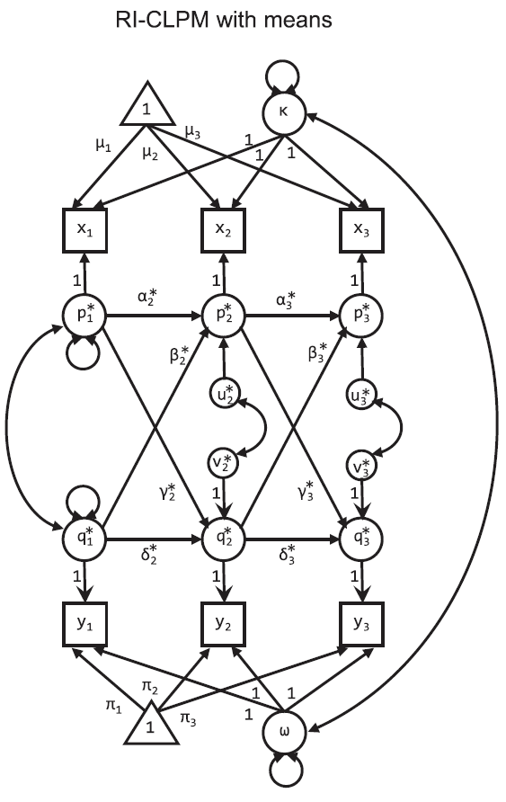

RI-CLPM Diagram

The first thing to not is the trick they use to separate out between and within person variance. It’s really cool actually. Instead of using the items directly, they model a mean structure for the items, and then essentially turn the residuals of that mean structure into single-indicator factors (with loadings fixed at 1). After you’ve “extracted” all the mean variance, you perform the cross-lagged analysis on the residuals via these factors. Read the paper for a less…casual…explantion.

# Example data

This is a crack at the code. Please let me know if you see something wrong.

First, we’ll load the data

```r
#install.packages('lavaan')
require(lavaan)
require(tidyverse)
data("Demo.growth")

knitr::kable(summary(Demo.growth))
```

|  | t1 | t2 | t3 | t4 | x1 | x2 | c1 | c2 | c3 | c4 |
| --- | --- | --- | --- | --- | --- | --- | --- | --- | --- | --- |
|  | Min. :-4.3534 | Min. :-4.8583 | Min. :-6.0166 | Min. :-7.338 | Min. :-2.82378 | Min. :-2.8262 | Min. :-2.577343 | Min. :-2.536319 | Min. :-3.39650 | Min. :-2.45499 |
|  | 1st Qu.:-0.3604 | 1st Qu.: 0.1589 | 1st Qu.: 0.8794 | 1st Qu.: 1.595 | 1st Qu.:-0.87877 | 1st Qu.:-0.5300 | 1st Qu.:-0.689172 | 1st Qu.:-0.574958 | 1st Qu.:-0.56944 | 1st Qu.:-0.61644 |
|  | Median : 0.6722 | Median : 1.8804 | Median : 2.7290 | Median : 3.721 | Median :-0.07608 | Median : 0.1300 | Median :-0.032083 | Median : 0.009501 | Median : 0.07427 | Median :-0.01404 |
|  | Mean : 0.5947 | Mean : 1.6733 | Mean : 2.5932 | Mean : 3.639 | Mean :-0.09210 | Mean : 0.1383 | Mean : 0.007788 | Mean : 0.028926 | Mean : 0.06764 | Mean :-0.01800 |
|  | 3rd Qu.: 1.6701 | 3rd Qu.: 3.0275 | 3rd Qu.: 4.4350 | 3rd Qu.: 5.825 | 3rd Qu.: 0.63925 | 3rd Qu.: 0.8165 | 3rd Qu.: 0.625950 | 3rd Qu.: 0.603897 | 3rd Qu.: 0.65894 | 3rd Qu.: 0.63575 |
|  | Max. : 5.2113 | Max. : 9.9472 | Max. :11.5305 | Max. :14.720 | Max. : 2.71832 | Max. : 2.8845 | Max. : 2.566558 | Max. : 2.710536 | Max. : 2.60935 | Max. : 2.65064 |

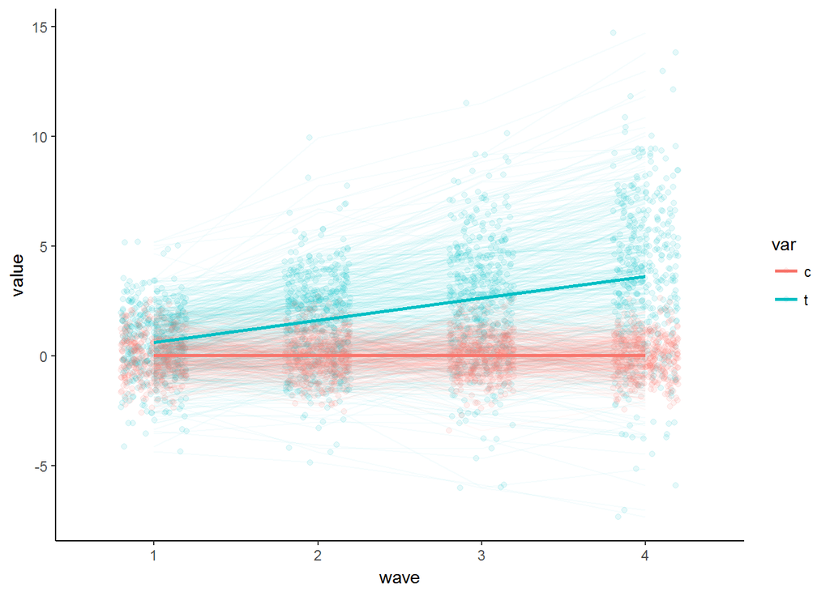

```r
Demo.growth %>%
  mutate(pid = 1:n()) %>%
  gather(key, value, -pid, -x1, -x2) %>%
  extract(col = key, into = c('var', 'wave'), regex = '(\\w)(\\d)') %>%
  ggplot(aes(x = wave, y = value, color = var, group = var)) +
  geom_point(position = position_jitter(w = .2), alpha = .1) +
  geom_line(stat = 'identity', aes(group = interaction(var, pid)), alpha = .04) +
  geom_line(stat = 'smooth', method = 'lm', size = 1) +
  theme_classic()
```

Well, look at that. The Demo.growth data has two time varrying variables, `t`, and `c`. Just right for our purposes.

In the below `lavaan` code, I’ll be using the notaiton from the diagram, except instead of “x” and “y”, I’ll use “t” and “c”. I am explicitly specifying everything in the diagram, which is why in the call to `lavaan` I set a bunch of `auto` options to false. This is because often lavaan will try to automatically estimate things that you don’t usually write out but often want estimated, like residuals. Because this model is unorthodox, I want to be as explicit as possible.

```r
riclpmModel <-
'
#Note, the data contain t1-3 and c1-3
#Latent mean Structure with intercepts

kappa =~ 1*t1 + 1*t2 + 1*t3
omega =~ 1*c1 + 1*c2 + 1*c3

t1 ~ mu1*1 #intercepts
t2 ~ mu2*1
t3 ~ mu3*1
c1 ~ pi1*1
c2 ~ pi2*1
c3 ~ pi3*1

kappa ~~ kappa #variance
omega ~~ omega #variance
kappa ~~ omega #covariance

#laten vars for AR and cross-lagged effects
p1 =~ 1*t1 #each factor loading set to 1
p2 =~ 1*t2
p3 =~ 1*t3
q1 =~ 1*c1
q2 =~ 1*c2
q3 =~ 1*c3

#constrain autoregression and cross lagged effects to be the same across both lags.
p3 ~ alpha3*p2 + beta3*q2
p2 ~ alpha2*p1 + beta2*q1

q3 ~ delta3*q2 + gamma3*p2
q2 ~ delta2*q1 + gamma2*p1

p1 ~~ p1 #variance
p2 ~~ u2*p2
p3 ~~ u3*p3
q1 ~~ q1 #variance
q2 ~~ v2*q2
q3 ~~ v3*q3

p1 ~~ q1 #p1 and q1 covariance
p2 ~~ q2 #p2 and q2 covariance
p3 ~~ q3 #p2 and q2 covariance'

fit <- lavaan(riclpmModel, data = Demo.growth,
              int.ov.free = F,
              int.lv.free = F,
              auto.fix.first = F,
              auto.fix.single = F,
              auto.cov.lv.x = F,
              auto.cov.y = F,
              auto.var = F)
summary(fit)
```

```
## lavaan (0.5-23.1097) converged normally after 103 iterations
##
##   Number of observations                           400
##
##   Estimator                                         ML
##   Minimum Function Test Statistic                0.883
##   Degrees of freedom                                 1
##   P-value (Chi-square)                           0.347
##
## Parameter Estimates:
##
##   Information                                 Expected
##   Standard Errors                             Standard
##
## Latent Variables:
##                    Estimate  Std.Err  z-value  P(>|z|)
##   kappa =~
##     t1                1.000
##     t2                1.000
##     t3                1.000
##   omega =~
##     c1                1.000
##     c2                1.000
##     c3                1.000
##   p1 =~
##     t1                1.000
##   p2 =~
##     t2                1.000
##   p3 =~
##     t3                1.000
##   q1 =~
##     c1                1.000
##   q2 =~
##     c2                1.000
##   q3 =~
##     c3                1.000
##
## Regressions:
##                    Estimate  Std.Err  z-value  P(>|z|)
##   p3 ~
```

[output cut: 41 more lines]

```
##                    Estimate  Std.Err  z-value  P(>|z|)
##     kappa            -9.863   14.987   -0.658    0.510
##     omega            -0.033    0.054   -0.607    0.544
##     p1               12.359   14.995    0.824    0.410
##    .p2        (u2)    1.829    0.129   14.148    0.000
##    .p3        (u3)    1.758    0.127   13.893    0.000
##     q1                1.005    0.089   11.270    0.000
##    .q2        (v2)    0.918    0.076   12.144    0.000
##    .q3        (v3)    0.895    0.081   10.986    0.000
##    .t1                0.000
##    .t2                0.000
##    .t3                0.000
##    .c1                0.000
##    .c2                0.000
##    .c3                0.000
```

I’m not sure why some variances are negative, except that this is probably an artificial data set. If you try this on your own real data and get the same problem, please let me know.

# References

Hamaker, Ellen L., Rebecca M. Kuiper, and P. P. P. 2015. “A Critique of the Cross-Lagged Panel Model.” *Psychological Methods* 20 (1): 102–16. doi:10.1037/a0038889.